# Statistical Learning B: Final Project

Diabetes Type II Prediction and Classification

Berke Furkan Kusmenoglu (2041496), Ivan Dragomirov Padezhki (2041499), Elisa Tremolada (2013013)

17/06/2022

# Libraries

Import necessary libraries for the analysis.

```r
library(tidyverse)
```

```r
library(MASS)
library(caret)
library(ggplot2)
library(corrplot)
library(ggcorrplot)
library(Hmisc)
library(corrplot)
library(RColorBrewer)
library(stats)
library(readr)
library(glmnet)
library(gridExtra)
library(grid)
library(car)
library(ROCR)
library(pROC)
```

# 1 Dataset

## 1.1 Introduction

The data set chosen for the current project is related to a paper exploring the connection between lifestyle, family history and Type 2 diabetes in the Indian population. The related article is Tigga, N. P., & Garg, S. (2020). Prediction of Type 2 Diabetes using Machine Learning Classification Methods. Procedia Computer Science, 167, 706-716. DOI: https://doi.org/10.1016/j.procs.2020.03.336. The data set can be found at https://www.kaggle.com/datasets/tigganeha4/diabetes-dataset-2019 and was first accessed on 30/05/2022.

## 1.2 Importing the data

```r
library(readr)
ds <- read_csv("https://raw.githubusercontent.com/ivanpadezhki/stat_learning_2/master/data/diabetes_dataset__2019.csv?token=GHSAT0AAAAAABTXCTNAD4HUUN5MUAT2TSDEYU6D7XA")
```

## 1.3 Data preprocessing

From a preliminary inspection we find three variables (‘BPLevel’, ‘Pdiabetes’, ‘Diabetes’) have received different codes for the same levels (e.g. some are lowercase, others start with a capital letter).

Moreover, we report below all levels for each variables, which will be useful to transform them into binary variables.

```r
for(i in 1:ncol(ds)) {
  print(lapply(ds[i], unique))
}
```

```
## $Age
## [1] "50-59"        "40-49"        "less than 40" "60 or older"
##
## $Gender
## [1] "Male"   "Female"
##
## $Family_Diabetes
## [1] "no"  "yes"
##
## $highBP
## [1] "yes" "no"
##
## $PhysicallyActive
## [1] "one hr or more"       "less than half an hr" "none"
## [4] "more than half an hr"
##
## $BMI
##  [1] 39 28 24 23 27 21 20 26 22 15 34 30 29 18 32 31 36 38 40 35 19 33 17 25 NA
## [26] 42 45
##
## $Smoking
## [1] "no"  "yes"
##
## $Alcohol
## [1] "no"  "yes"
##
## $Sleep
## [1]  8  6 10  7 11  9  4  5
##
## $SoundSleep
##  [1]  6  8 10  7 11  4  9  5  3  2  1  0
##
## $RegularMedicine
## [1] "no"  "yes" "o"
##
## $JunkFood
## [1] "occasionally" "very often"   "often"        "always"
##
## $Stress
## [1] "sometimes"  "not at all" "very often" "always"
##
## $BPLevel
## [1] "high"   "normal" "low"    "Low"    "High"
##
## $Pregancies
## [1]  0  1  2  3  4 NA
##
## $Pdiabetes
## [1] "0"   "yes" NA    "no"
##
## $UriationFreq
## [1] "not much"    "quite often"
##
## $Diabetic
## [1] "no"  "yes" NA
```

### 1.3.1 Normalization of value labels

```r
# Copy data into a new variable to retain original data frame
ds_fin <- ds

# Fixing variable name Pregancies
ds_fin <- ds_fin %>% rename(Pregnancies=Pregancies)

#Fixing the variable Pdiabetes
ds_fin$Pdiabetes[ds_fin$Pdiabetes == ''] <- NA
ds_fin$Pdiabetes[ds_fin$Pdiabetes == ' no'] <- 'no'
ds_fin$Pdiabetes[ds_fin$Pdiabetes == '0'] <- 'no'

#Fixing the variable Diabetic
ds_fin$Diabetic[ds_fin$Diabetic == ' no'] <- 'no'
ds_fin$Diabetic[ds_fin$Diabetic == ''] <- NA

#Fixing the variable BPLevel
ds_fin$BPLevel[ds_fin$BPLevel == 'High'] <- 'high'
ds_fin$BPLevel[ds_fin$BPLevel == 'Low'] <- 'low'
ds_fin$BPLevel[ds_fin$BPLevel == 'normal '] <- 'normal'

# Fixing the variable RegularMedicine
ds_fin$RegularMedicine[ds_fin$RegularMedicine == 'o'] <- 'no'
```

### 1.3.2 Identifying Missing Values

The whole data set contains 48 missing values; in light of the relatively large number of observations (952), the rows containing NA values will be removed from the data set prior to analysis.

```r
sum(is.na(ds_fin)==TRUE)
```

```
## [1] 48
```

First, we investigate the rows with missing values to identify potential patterns.

In fact, most of the missing values are in the variable ‘Pregnancies’. The research paper provides no explanation for the high number of NAs in this variable. Furthermore, the NAs are present for both female and male individuals, so there is not a reason to suspect a pattern.

Thus, the rows containing missing values are removed from the data set.

```r
ds_fin[rowSums(is.na(ds_fin)) > 0, ]
```

```
## # A tibble: 47 x 18
##    Age     Gender Family_Diabetes highBP PhysicallyActive    BMI Smoking Alcohol
##    <chr>   <chr>  <chr>           <chr>  <chr>             <dbl> <chr>   <chr>
##  1 less t~ Female yes             no     more than half a~    NA no      no
##  2 less t~ Female no              no     more than half a~    NA no      no
##  3 50-59   Female yes             yes    none                 NA no      no
##  4 less t~ Male   no              yes    more than half a~    NA no      no
##  5 less t~ Male   yes             no     one hr or more       20 no      no
##  6 less t~ Male   yes             no     more than half a~    21 yes     no
##  7 less t~ Female yes             no     one hr or more       26 no      no
##  8 less t~ Female yes             no     none                 21 no      yes
##  9 less t~ Female yes             no     none                 21 no      yes
## 10 less t~ Female yes             no     more than half a~    24 no      no
## # ... with 37 more rows, and 10 more variables: Sleep <dbl>, SoundSleep <dbl>,
## #   RegularMedicine <chr>, JunkFood <chr>, Stress <chr>, BPLevel <chr>,
## #   Pregnancies <dbl>, Pdiabetes <chr>, UriationFreq <chr>, Diabetic <chr>
```

```r
ds_fin <- na.omit(ds_fin)
```

#### 1.3.2.1 Identifying weird observations

A later check of the data led to the discovery of 12 individuals coded as “Male” who at the same time have a value larger than 0 for the variable Pregnancies. Since the chance of having 12 transgender men who have had 1 or more pregnancies in our data set are rather low, these observations are excluded from further analyses.

```r
preg_male <- subset(ds_fin, Gender == 'Male' & Pregnancies != 0)
# Take a closer look at the observations to potentially identify if it is a data entry mistake
preg_male
```

```
## # A tibble: 12 x 18
##    Age     Gender Family_Diabetes highBP PhysicallyActive    BMI Smoking Alcohol
##    <chr>   <chr>  <chr>           <chr>  <chr>             <dbl> <chr>   <chr>
##  1 40-49   Male   no              no     more than half a~    23 no      no
##  2 60 or ~ Male   no              yes    less than half a~    19 no      yes
##  3 less t~ Male   no              no     more than half a~    30 yes     yes
##  4 40-49   Male   no              no     more than half a~    23 no      no
##  5 60 or ~ Male   no              yes    less than half a~    19 no      yes
##  6 less t~ Male   no              no     more than half a~    30 yes     yes
##  7 40-49   Male   no              no     more than half a~    23 no      no
##  8 60 or ~ Male   no              yes    less than half a~    19 no      yes
##  9 less t~ Male   no              no     more than half a~    30 yes     yes
## 10 40-49   Male   no              no     more than half a~    23 no      no
## 11 60 or ~ Male   no              yes    less than half a~    19 no      yes
## 12 less t~ Male   no              no     more than half a~    30 yes     yes
## # ... with 10 more variables: Sleep <dbl>, SoundSleep <dbl>,
## #   RegularMedicine <chr>, JunkFood <chr>, Stress <chr>, BPLevel <chr>,
## #   Pregnancies <dbl>, Pdiabetes <chr>, UriationFreq <chr>, Diabetic <chr>
```

```r
# exclude individuals from data set
ds_fin <- ds_fin[!(ds_fin$Gender == 'Male' & ds_fin$Pregnancies != 0),]
```

### 1.3.3 Turning categorical variables into dummy variables

Binary variables with yes/no as levels are coded as 1 versus 0.

For variables with more than two levels, the lowest level is taken as baseline and the rest are contrasted with it.

The reason for this choice of dummy coding is that none of the categorical variables are nominally scaled, rather they are ordinal variables without measurable distances between different levels. Therefore, coding them as numerical variables is not appropriate.

The end result is a data set containing 26 predictor variables.

```r
# Keep ds_pre for creating labeled plots easier later
ds_pre <- ds_fin


# Variable AGE - has 4 levels, cast into 3 dummy variables with baseline <40 yo
ds_fin$Age40_49 <- ifelse(ds_fin$Age == "40-49", 1, 0)
ds_fin$Age50_59 <- ifelse(ds_fin$Age == "50-59", 1, 0)
ds_fin$Age_60 <- ifelse(ds_fin$Age == "60 or older", 1, 0)
ds_fin$Age <- NULL

# Variable GENDER (has two levels: male/female)
ds_fin$Gender_M <- ifelse(ds_fin$Gender == "Male", 1, 0)
ds_fin$Gender <- NULL

# Variable FAMILY DIABETES - has two levels (yes/no)
ds_fin$Family_Diabetes <- ifelse(ds_fin$Family_Diabetes == "yes", 1, 0)

# Variable high blood pressure - has two levels (yes/no)
ds_fin$highBP <- ifelse(ds_fin$highBP == "yes", 1, 0)

# Variable Physically Active: has 4 levels: none/ less than 30 min/ more than 30 min/ more than 1 hr
# cast into three dummy variables with "none" as baseline
ds_fin$PhysLow <- ifelse(ds_fin$PhysicallyActive == "less than half an hr", 1, 0)
ds_fin$PhysMid <- ifelse(ds_fin$PhysicallyActive == "more than half an hr", 1, 0)
ds_fin$PhysHigh <- ifelse(ds_fin$PhysicallyActive == "one hr or more", 1, 0)
ds_fin$PhysicallyActive <- NULL

#Vairable BMI: we know from the paper underlying the dataset that having a BMI>25 is considered an
#important risk factor for developing diabetes. Hence, we turn BMI into a dummy variable,
# taking value=0 when the subject has BMI < 25 and value 1 when BMI >= 25.

ds_fin$BMI <- ifelse(ds_fin$BMI >= 25, 1, 0)

# Variable Smoking - has two levels (yes/no)
ds_fin$Smoking <- ifelse(ds_fin$Smoking == "yes", 1, 0)

# Variable Alcohol - has two levels (yes/no)
ds_fin$Alcohol <- ifelse(ds_fin$Alcohol == "yes", 1, 0)

# Variable Regular Medicine - has two levels yes/no
ds_fin$RegularMedicine <- ifelse(ds_fin$RegularMedicine == "yes", 1, 0)

# Variable Junk Food - contains 4 levels: occasionally/ often/ very often/ always
ds_fin$JunkOften <- ifelse(ds_fin$JunkFood == "often", 1, 0)
ds_fin$JunkVeryOften <- ifelse(ds_fin$JunkFood == "very often", 1, 0)
ds_fin$JunkAlways <- ifelse(ds_fin$JunkFood == "always", 1, 0)
ds_fin$JunkFood <- NULL

# Variable Stress has 4 levels: not at all/ sometimes/ very often/ always
ds_fin$StressSometimes <- ifelse(ds_fin$Stress == "sometimes", 1, 0)
ds_fin$StressOften <- ifelse(ds_fin$Stress == "very often", 1, 0)
ds_fin$StressAlways <- ifelse(ds_fin$Stress == "always", 1, 0)
ds_fin$Stress <- NULL

# Variable BPLevel - similar to highBP, but has three levels (low/normal/high)
ds_fin$BPNormal <- ifelse(ds_fin$BPLevel == "normal", 1, 0)
ds_fin$BPHigh <- ifelse(ds_fin$BPLevel == "high", 1, 0)
ds_fin$BPLevel <- NULL

# Variable PDiabetes: Gestational Diabetes (during pregnancy) - contains yes/no
ds_fin$Pdiabetes <- ifelse(ds_fin$Pdiabetes == "yes", 1, 0)

# Variable Urination Frequency with two levels - not much/ quite often
ds_fin$UriationFreq <- ifelse(ds_fin$UriationFreq == "quite often", 1, 0)

# Outcome Variable Diabetic with two levels - yes/ no
ds_fin$Diabetic <- ifelse(ds_fin$Diabetic == "yes", 1, 0)
```

Finally, we perform a check of the transformation.

```r
# this for-loop returns an output only if a certain variable is not numeric

for(i in 1:ncol(ds_fin)) {
  if (lapply(ds_fin[1], class) != 'numeric'){
    print(lapply(ds_fin[i], class))
  }
}
```

### 1.3.4 Checking numerical variables

```r
mean(ds_fin$BMI)
```

```
## [1] 0.4871221
```

```r
sd(ds_fin$BMI)
```

```
## [1] 0.5001142
```

```r
mean(ds_fin$Sleep)
```

```
## [1] 6.969765
```

```r
sd(ds_fin$Sleep)
```

```
## [1] 1.288177
```

```r
mean(ds_fin$SoundSleep)
```

```
## [1] 5.554311
```

```r
sd(ds_fin$SoundSleep)
```

```
## [1] 1.879979
```

## 1.4 Exploratory Data Analysis: Graphical EDA

An important question is whether the outcome variable is balanced. In the current data set, our class of interest (diabetic subjects) has less than half the observations with respect to non-diabetic subjects.

Since this is not a large imbalance, the analyses will be performed without any data over/undersampling.

However, the development of this problem will be monitored throughout the analysis, especially in the diagnosis of the model.

```r
table(ds_fin$Diabetic)
```

```
##
##   0   1
## 632 261
```

In this section we produce some plots, with the intention of better understanding the distribution of the predictor variables in our dataset - both with respect to each other and with respect to the output variable “Diabetic”.

### 1.4.1 Numerical Variables

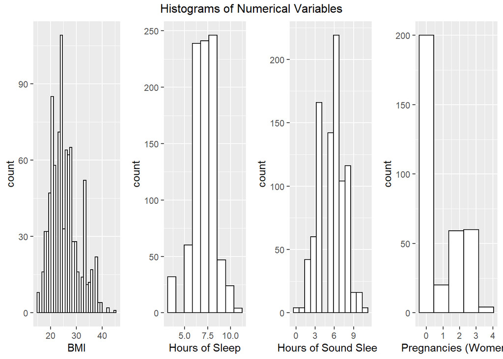

```r
# histogram of numerical variables
hist_bmi <- ggplot(ds_pre, aes(x=BMI)) +
  geom_histogram(color="black", fill="white", binwidth = 0.9) + labs(x = "BMI")
hist_sleep <- ggplot(ds_fin, aes(x=Sleep)) +
  geom_histogram(color="black", fill="white", binwidth = 0.9) + labs(x = "Hours of Sleep")
hist_soundsl <- ggplot(ds_fin, aes(x=SoundSleep)) +
  geom_histogram(color="black", fill="white", binwidth = 0.9) + labs(x = "Hours of Sound Sleep")
hist_preg <- ggplot(ds_fin[ds_fin$Gender_M!=1,], aes(x=Pregnancies)) +
  geom_histogram(color="black", fill="white", binwidth = 0.9) + labs(x = "Pregnancies (Women)")
grid.arrange(hist_bmi, hist_sleep, hist_soundsl, hist_preg, ncol = 4, top=textGrob("Histograms of Numerical Variables"))
```

Furthermore, the relationship of the numerical variables with the outcome variable is explored. There doesn’t seem to be a reason to expect large differences in the outcome variable based on the three numerical variables studied below.

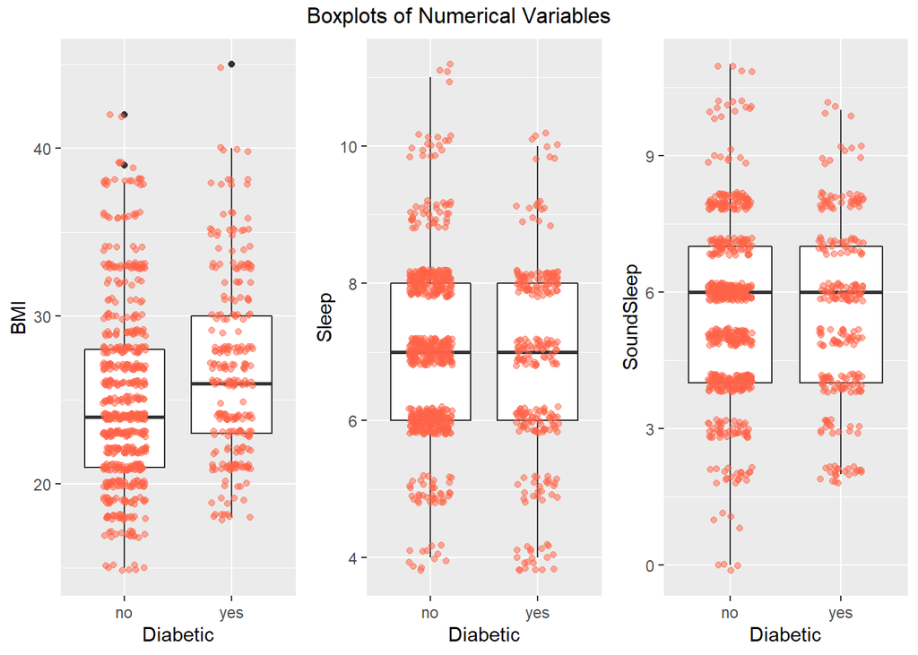

```r
box_bmi <- ggplot(ds_pre, aes(x=Diabetic, y=BMI)) +
    geom_boxplot() +
  geom_jitter(alpha = 0.5, width = 0.2, height = 0.2, color = "tomato")
box_sleep <- ggplot(ds_pre, aes(x=Diabetic, y=Sleep)) +
    geom_boxplot() +
  geom_jitter(alpha = 0.5, width = 0.2, height = 0.2, color = "tomato")
box_ssleep <- ggplot(ds_pre, aes(x=Diabetic, y=SoundSleep)) +
    geom_boxplot() +
  geom_jitter(alpha = 0.5, width = 0.2, height = 0.2, color = "tomato")
grid.arrange(box_bmi, box_sleep, box_ssleep, ncol = 3, top=textGrob("Boxplots of Numerical Variables"))
```

Additionally, the relationship between Sleep and Sound Sleep is evaluated. There seems to be reason to suspect possible interaction between the two variables, potentially due to correlation. For this reason, in a future model we will consider excluding one of the two variables.

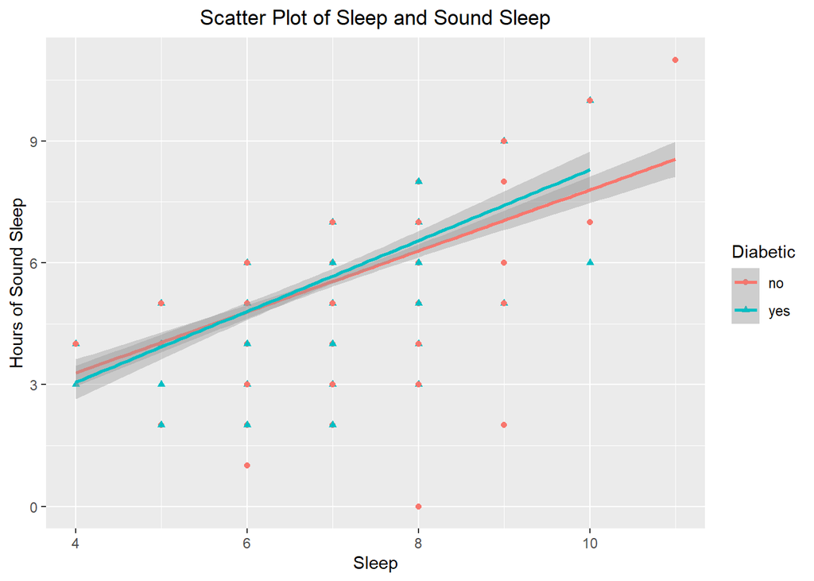

```r
ggplot(ds_pre, aes(x=Sleep, y=SoundSleep, shape = Diabetic, color = Diabetic)) + geom_point() +
  geom_smooth(method=lm, level=0.95) +
  labs(y = "Hours of Sound Sleep", title = "Scatter Plot of Sleep and Sound Sleep") +
  # move the title text to the middle
  theme(plot.title=element_text(hjust=0.5))
```

### 1.4.2 Categorical variables

Next, we inspect the categorical variables and their relationships.

```r
get_legend<-function(myggplot){
  tmp <- ggplot_gtable(ggplot_build(myggplot))
  leg <- which(sapply(tmp$grobs, function(x) x$name) == "guide-box")
  legend <- tmp$grobs[[leg]]
  return(legend)
}
```

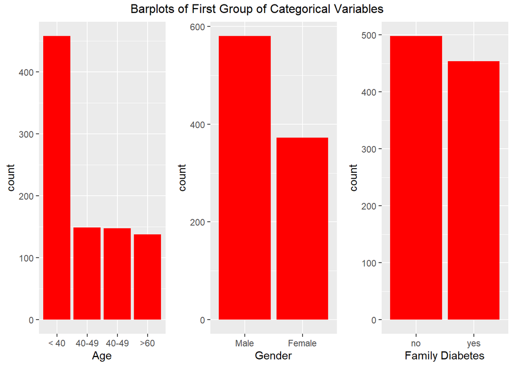

```r
# build plots
bar_age <- ggplot(ds_pre, aes(x=reorder(Age, Age, function(x)-length(x)))) +
   geom_bar(fill='red') +  labs(x='Age') +
  scale_x_discrete(labels=c("less than 40" = "< 40", "40-49" = "40-49",
                              "50-59" = "40-49", "60 or older" = ">60"))
bar_gender <- ggplot(ds, aes(x=reorder(Gender, Gender, function(x)-length(x)))) +
   geom_bar(fill='red') +  labs(x='Gender')
bar_familyd <- ggplot(ds, aes(x=reorder(Family_Diabetes, Family_Diabetes, function(x)-length(x)))) +
   geom_bar(fill='red') +  labs(x='Family Diabetes')

bar_smoking <- ggplot(data = ds_pre, aes(x = Smoking)) +
    geom_bar() + theme(legend.position = "none")
bar_alc <- ggplot(data = ds_pre, aes(x = Alcohol)) +
    geom_bar() + theme(legend.position = "none")
bar_med <- ggplot(data = ds_pre, aes(x = RegularMedicine)) +
  geom_bar() + theme(legend.position="none")
# reorder Stress levels
ds_pre$Stress <- factor(ds_pre$Stress,levels = c("not at all", "sometimes", "very often", "always"))
# plot Stress
bar_stress <- ggplot(data = ds_pre, aes(x = Stress)) +
  geom_bar() +
  theme(legend.position = "none", axis.text.x = element_text(angle = 45, vjust = 1, hjust=1)) +
  scale_x_discrete(labels=c("not at all" = "none.", "sometimes" = "somet.",
                              "very often" = "v. often", "always" = "alw."))

# reorder levels of JunkFood
ds_pre$JunkFood <- factor(ds_pre$JunkFood,levels = c("occasionally", "often", "very often", "always"))
bar_junk <- ggplot(data = ds_pre, aes(x = JunkFood)) +
    geom_bar() + theme(legend.position = "none", axis.text.x = element_text(angle = 45, vjust = 1, hjust=1)) +
   scale_x_discrete(labels=c("occasionally" = "occas.", "often" = "often",
                              "very often" = "v. often", "always" = "alw."))

# reorder levels of Physical Activity
ds_pre$PhysicallyActive <- factor(ds_pre$PhysicallyActive,levels = c("none", "less than half an hr", "more than half an hr", "one hr or more"))
# plot physical activity
bar_act <- ggplot(data = ds_pre, aes(x = PhysicallyActive)) +
    geom_bar() + theme(legend.position = "none", axis.text.x = element_text(angle = 45, vjust = 1, hjust=1)) +
  scale_x_discrete(labels=c("none" = "none", "less than half an hr" = "<30 m",
                              "more than half an hr" = ">30 m", "one hr or more" = ">1 hr"))

bar_urin <- ggplot(data = ds_pre, aes(x = UriationFreq)) +
    geom_bar() + theme(legend.position = "none")
# reorder BPlevel to be low, normal, high
ds_pre$BPLevel <- factor(ds_pre$BPLevel,levels = c("low", "normal", "high"))
# plot BPLevel
bar_bplev <- ggplot(data = ds_pre, aes(x = BPLevel)) +
    geom_bar() + theme(legend.position="none")
bar_highbp <- ggplot(data = ds_pre, aes(x = highBP)) +
  geom_bar() + theme(legend.position="none")

# Plot first group
grid.arrange(bar_age, bar_gender, bar_familyd, ncol = 3, top=textGrob("Barplots of First Group of Categorical Variables"))
```

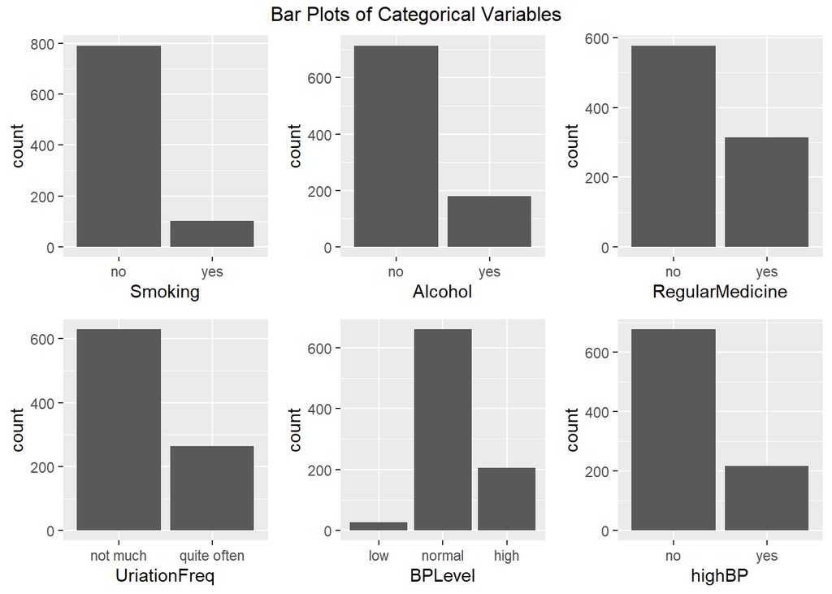

```r
# plot second group
grid.arrange(bar_smoking, bar_alc, bar_med, bar_urin, bar_bplev, bar_highbp, ncol = 3, top=textGrob("Bar Plots of Categorical Variables"))
```

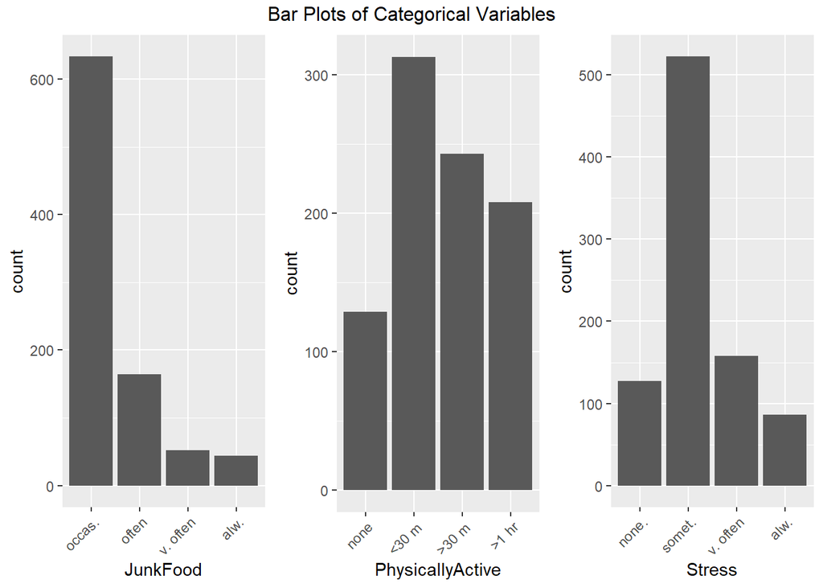

```r
# plot third group
grid.arrange(bar_junk, bar_act, bar_stress, ncol = 3, top=textGrob("Bar Plots of Categorical Variables"))
```

Create proportional plots for relevant variables and their relationship with the outcome variable.

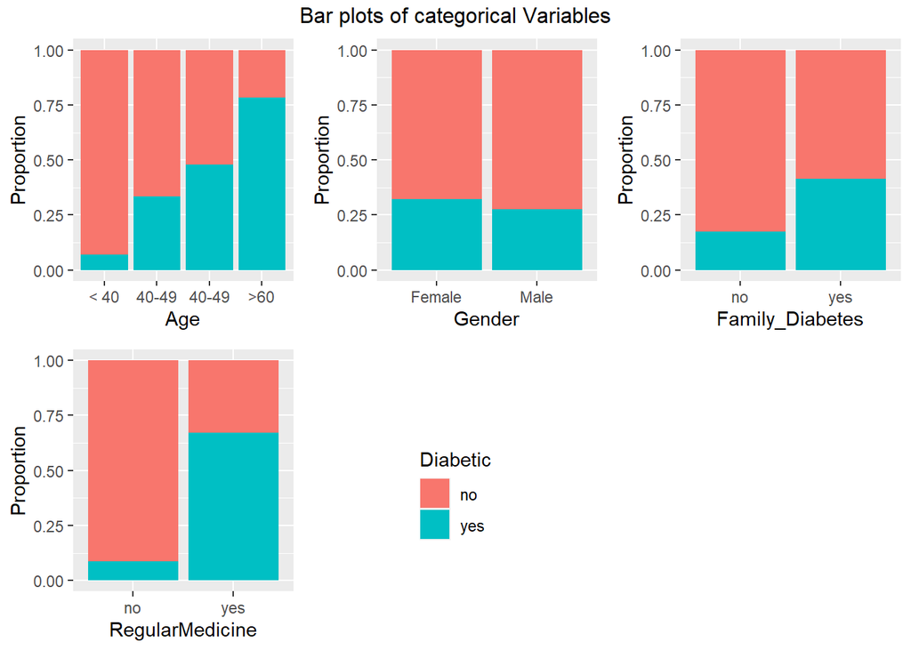

```r
# Variable Age
# reorder levels
ds_pre$Age <- factor(ds_pre$Age,levels = c("less than 40", "40-49", "50-59", "60 or older"))
prop_age <- ggplot(data = ds_pre, aes(x = Age, fill = Diabetic)) +
  geom_bar(position = 'fill') +
  theme(legend.position = 'none') +
  labs(y = 'Proportion') +
  scale_x_discrete(labels=c("less than 40" = "< 40", "40-49" = "40-49",
                              "50-59" = "40-49", "60 or older" = ">60"))
# Gender
prop_gender <- ggplot(data = ds_pre, aes(x = Gender, fill = Diabetic)) +
  geom_bar(position = 'fill') +
  theme(legend.position = 'none') +
  labs(y = 'Proportion')
# Family Diabetes
prop_famdiab <- ggplot(data = ds_pre, aes(x = Family_Diabetes, fill = Diabetic)) +
  geom_bar(position = 'fill') +
  theme(legend.position = 'none') +
  labs(y = 'Proportion')
# Junk Food
prop_junk <- ggplot(data = ds_pre, aes(x = JunkFood, fill = Diabetic)) +
  geom_bar(position = 'fill') +
  theme(legend.position = "none", axis.text.x = element_text(angle = 45, vjust = 1, hjust=1)) +
  labs(y = "Proportion") +
  scale_x_discrete(labels=c("occasionally" = "occas.", "often" = "often",
                              "very often" = "v. often", "always" = "alw."))
# Alcohol
prop_alc <- ggplot(data = ds_pre, aes(x = Alcohol, fill = Diabetic)) +
  geom_bar(position = 'fill') + theme(legend.position = "none") + labs(y = "Proportion")
# Physical Activity
prop_act <- ggplot(data = ds_pre, aes(x = PhysicallyActive, fill = Diabetic)) +
  geom_bar(position = 'fill') +
  theme(legend.position = "none", axis.text.x = element_text(angle = 45, vjust = 1, hjust=1)) +
  labs(y = "Proportion") +
  scale_x_discrete(labels=c("none" = "none", "less than half an hr" = "<30 m",
                              "more than half an hr" = ">30 m", "one hr or more" = ">1 hr"))
# Regular Medicine
prop_med <- ggplot(data = ds_pre, aes(x = RegularMedicine, fill = Diabetic)) +
  geom_bar(position = 'fill') + theme(legend.position="none") + labs(y = "Proportion")
# Smoking
prop_smoke <- ggplot(data = ds_pre, aes(x = Smoking, fill = Diabetic)) +
  geom_bar(position = 'fill') + theme(legend.position = "none") + labs(y = "Proportion")
# Stress
prop_stress <- ggplot(data = ds_pre, aes(x = Stress, fill = Diabetic)) +
  geom_bar(position = 'fill') +
  theme(legend.position = "none", axis.text.x = element_text(angle = 45, vjust = 1, hjust=1)) +
  labs(y = "Proportion") +
  scale_x_discrete(labels=c("not at all" = "none.", "sometimes" = "somet.",
                              "very often" = "v. often", "always" = "alw."))
# Blood Pressure Level
prop_bplev <- ggplot(data = ds_pre, aes(x = BPLevel, fill = Diabetic)) +
    geom_bar(position = 'fill') + theme(legend.position="none")
# High Blood pressure
prop_highbp <- ggplot(data = ds_pre, aes(x = highBP, fill = Diabetic)) +
  geom_bar(position = 'fill') + theme(legend.position="none")
# Urination Frequency
prop_urin <- ggplot(data = ds_pre, aes(x = UriationFreq, fill = Diabetic)) +
    geom_bar(position = 'fill')
# get legend
legend <- get_legend(prop_urin)
# delete legend from past plot
prop_urin <- prop_urin + theme(legend.position="none")

# Create graph with multiple plots
grid.arrange(prop_age, prop_gender, prop_famdiab, prop_med, legend, ncol = 3, top=textGrob("Bar plots of categorical Variables"))
```

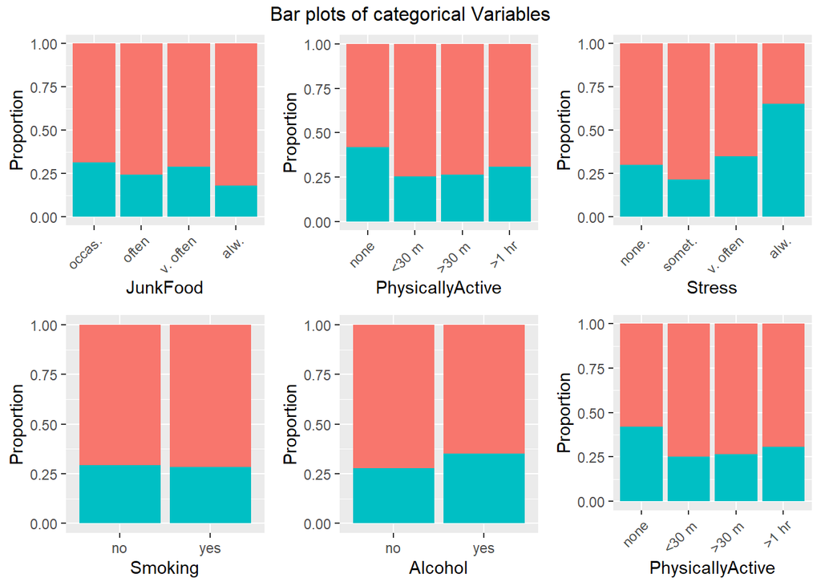

```r
grid.arrange(prop_junk, prop_act, prop_stress, prop_smoke, prop_alc, prop_act, ncol = 3, top=textGrob("Bar plots of categorical Variables"))
```

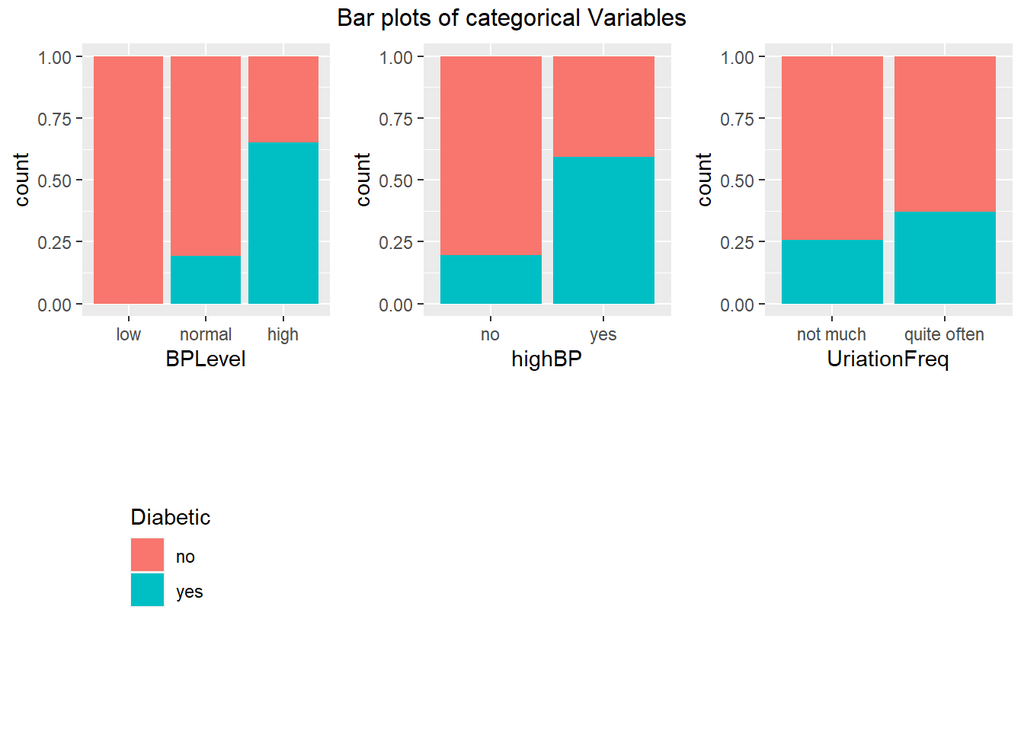

```r
grid.arrange(prop_bplev, prop_highbp, prop_urin, legend, ncol = 3, top=textGrob("Bar plots of categorical Variables"))
```

### 1.4.3 Further exploration

Then, we take a look at some relationships between categorical and numerical variables

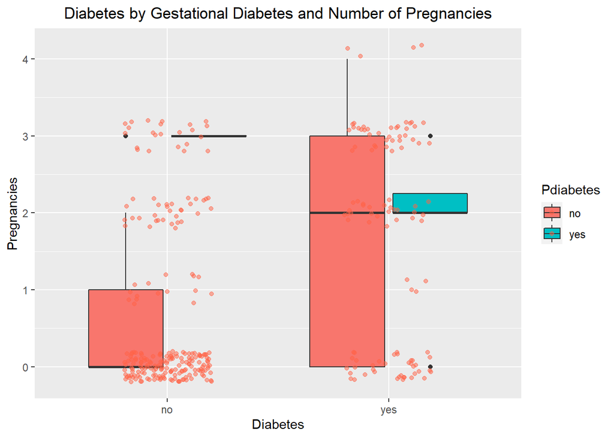

```r
gender_f <- ds_pre[ds_pre$Gender=='Female',]
ggplot(gender_f, aes(x=Diabetic, y=Pregnancies, fill = Pdiabetes)) +
  geom_boxplot() +
  geom_jitter(alpha = 0.5, width = 0.2, height = 0.2, color = "tomato") +
  labs(x = "Diabetes", y = "Pregnancies", title = "Diabetes by Gestational Diabetes and Number of Pregnancies")+
  # move the title text to the middle
  theme(plot.title=element_text(hjust=0.5))
```

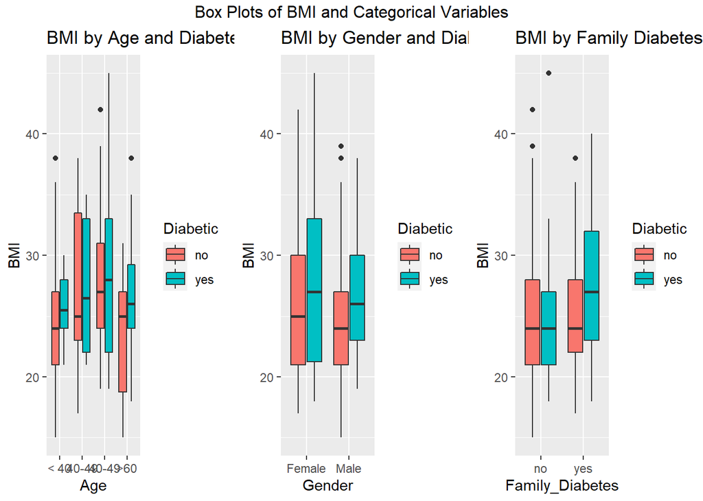

```r
box_alc.bmi <- ggplot(ds_pre, aes(x=Alcohol, y=BMI, fill = Diabetic)) +
    geom_boxplot() + labs(title = "BMI by Alcohol Consumption and Diabetes")
box_age.bmi <- ggplot(ds_pre, aes(x=Age, y=BMI, fill = Diabetic)) +
    geom_boxplot() + labs(title = "BMI by Age and Diabetes") +
  scale_x_discrete(labels=c("less than 40" = "< 40", "40-49" = "40-49",
                              "50-59" = "40-49", "60 or older" = ">60"))
box_gender.bmi <- ggplot(ds_pre, aes(x=Gender, y=BMI, fill = Diabetic)) +
    geom_boxplot() + labs(title = "BMI by Gender and Diabetes")
box_smoke.bmi <- ggplot(ds_pre, aes(x=Smoking, y=BMI, fill = Diabetic)) +
    geom_boxplot() + labs(title = "BMI by Smoking and Diabetes")
box_fam.bmi <- ggplot(ds_pre, aes(x=Family_Diabetes, y=BMI, fill = Diabetic)) +
    geom_boxplot() + labs(title = "BMI by Family Diabetes and Diabetes")
box_highbp.bmi <- ggplot(ds_pre, aes(x=highBP, y=BMI, fill = Diabetic)) +
    geom_boxplot() + labs(title = "BMI by High Blood Pressure and Diabetes")
box_med.bmi <- ggplot(ds_pre, aes(x=RegularMedicine, y=BMI, fill = Diabetic)) +
    geom_boxplot() + labs(title = "BMI by Regular Medicine and Diabetes")
box_urin.bmi <- ggplot(ds_pre, aes(x=UriationFreq, y=BMI, fill = Diabetic)) +
    geom_boxplot() + labs(title = "BMI by Urination Frequency and Diabetes")
box_pdiab.bmi <- ggplot(gender_f, aes(x=Pdiabetes, y=BMI, fill = Diabetic)) +
    geom_boxplot() + labs(title = "BMI by Gestational Diabetes and Diabetes")

grid.arrange(box_age.bmi, box_gender.bmi, box_fam.bmi,
             ncol = 3, top=textGrob("Box Plots of BMI and Categorical Variables"))
```

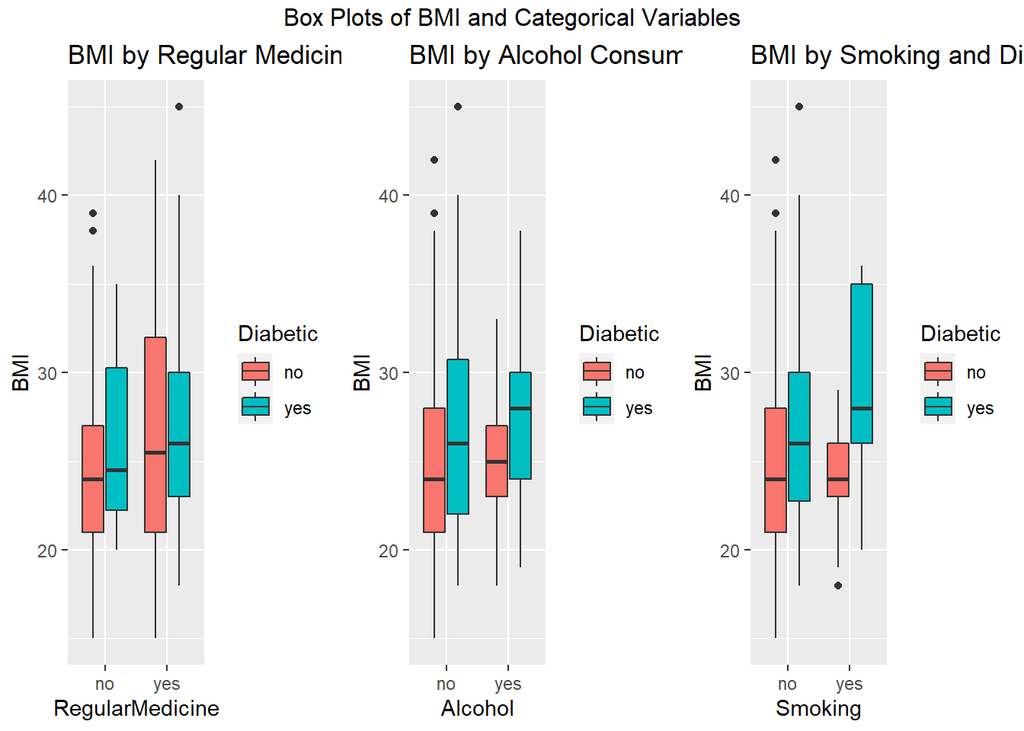

```r
grid.arrange(box_med.bmi, box_alc.bmi, box_smoke.bmi,
             ncol = 3, top=textGrob("Box Plots of BMI and Categorical Variables"))
```

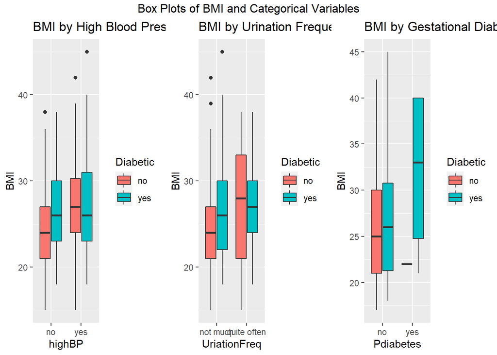

```r
grid.arrange(box_highbp.bmi, box_urin.bmi, box_pdiab.bmi,
             ncol = 3, top=textGrob("Box Plots of BMI and Categorical Variables"))
```